# The Microfilling

Microeconomic Decision-making

# Resources

[video not shown]

[03 Slides - The Microfilling - Microeconomic Decision-making](https://drive.google.com/file/d/1DKrX4dt9x4qDx9f85-MPPbYeE7yCOf2m/view?usp=sharing)

## Readings

No reading for today. All fresh content.

## Utility Maximization Games

Play them in order (preferred).

- Utility Maximization Explanation
- Drag-the-Isoquant
- Choose-the-Goods
- Utility in 4d (really?)
- Utility in 5d (um….when will this end)
- Utility in 15d (seriously?)

# Content

## Introduction: The Micro-Filling of the Planetary Donut

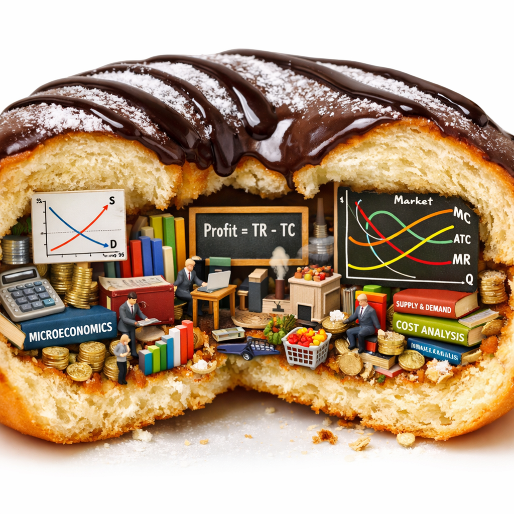

One of the central themes of this course is the concept of the planetary donut from Kate Raworth, which was introduced in the previous lecture when examining sustainability indicators. This lecture goes considerably further than Raworth’s original book, which did not cover the material presented here. The contention throughout this course is that economics is genuinely valuable for a variety of reasons, and one of the most important is that it possesses a remarkably coherent theory explaining why people make the decisions they do.

Working in environmental spaces often means finding oneself in the position of an apologist for economists. This is because environmental circles frequently include people who view economists negatively, seeing them as mere representatives of the capitalist system. The constant effort involves arguing for the importance of both environment and economics simultaneously. This lecture demonstrates why economics has value and what tools an economics major can bring to environmental problems.

The concept of the “micro-filling” captures this idea: when the planetary donut is embedded in a detailed economic model, it contains tremendous depth and valuable details that enable predictions about human behavior. While AI-generated images can now produce reasonable-looking supply and demand curves, they still make errors that an undergraduate would be marked down for, such as having the minimum of the marginal revenue curve fail to intersect the average total cost curve properly.

## Utility Theory: The Foundation of Welfare Economics

### What Is Utility?

The specific focus of this lecture is utility. Utility is the fundamental concept that economists use to argue that the policies of the invisible hand or the free market are beneficial. Before exploring utility in detail, it is necessary to understand the tools of utility, utility curves, and how individuals who are assumed to be rational will optimize their utility. This involves the tools of constrained optimization.

This discussion falls within the broader goal of maximizing welfare. If unlimited resources existed, the question would be trivial since one could simply have unlimited consumer goods. In reality, however, choices are constrained by budgets. The lecture will tie these concepts back to environmental aspects and explain how they will be used throughout the semester.

### Philosophical Origins: Utilitarianism

It is useful to consider the philosophical origins of utility theory. Modern welfare economics grows directly out of utilitarian moral philosophy. The term “welfare” in economics has a very specific meaning that differs entirely from how most people use the word. Most people think of government assistance programs when they hear “welfare.” Those programs are named for their aim of increasing welfare, but economists use the term to mean something quite specific related to utility maximization and consumer and producer surplus.

The philosophical basis comes from Jeremy Bentham and John Stuart Mill, who were the two most notable proponents of utilitarianism. This philosophy is appealing partly because it can be summarized simply. The most common phrase is “the greatest good for the greatest number of people.” To use their actual quotes, “the right action is the one that maximizes total happiness.”

Utilitarianism has been used extensively throughout policy analysis. However, it is very different from a rights-based approach. While utilitarianism sounds entirely positive, there exists a substantial philosophical disagreement about whether utilitarianism is the correct way to think about morals, or whether a rights-based approach is superior. These two frameworks are fundamentally in conflict. If one says there is a right to free speech, free expression, protest, or not being detained, that right might conflict with what utilitarianism prescribes, because a utilitarian might argue that such a right prevents doing the thing that would maximize utility.

A deep philosophical debate surrounds these issues, but this course will not dive deeply into philosophy. Instead, it will use utilitarianism because it is useful from a pragmatic standpoint. In economics, this framing proves valuable because it can be taken quite far. The approach posits that each person has a utility function, that social welfare is basically some aggregation of everybody’s utility functions, and that therefore the utilitarian or normative good policy would simply be the one that maximizes the sum of utilities.

### Challenges with Utility Theory

Before unpacking utility theory in detail, it is important to discuss its challenges from the beginning rather than presenting the complete theory and only mentioning challenges at the end.

#### The Ordinal Nature of Utility

The first challenge is that utilities are ordinal, meaning only the order can be determined. When using utility as a concept, one can easily say that one bundle of goods gives more utility than another bundle, creating a ranking or order of different consumption choices. This is what ordinal means.

This differs from something cardinal, where an actual measurement is obtained. A cardinal measurement would be like that of a thermometer: inserting a thermometer and getting 98 degrees actually means something specific. But with utility, the situation is different. A number will be obtained when using utility functions, but it does not mean anything in the same way. There is no unit of utility like there is a unit of temperature. The first challenge, therefore, is that utility is hard to measure and is private, meaning it cannot be observed directly. Dealing with something that is unobservable directly is inherently difficult. Nevertheless, there are ways to learn a great deal about its shape.

#### Aggregation Challenges

The second set of challenges involves aggregation. The idea of summing together individual utility functions was mentioned briefly, but this turns out to be extremely challenging to do in a value-free way. However utilities are summed together, values are fundamentally involved. If utilities are summed equally, that expresses a view that equality matters. Alternatively, they might be summed according to some distribution rule, such as ensuring nobody is extremely poor. These considerations are especially important because how society’s welfare is aggregated into a utility function representing everybody is fundamentally challenging in terms of debates between equality versus efficiency.

This tension will appear extensively in upcoming classes, particularly with respect to present value versus future generations. How much to care about someone born 100 years from now who may be struggling with an unstable climate is a genuinely difficult question. The discussion will return to this extensively when examining the discount rate.

## Revealed Preferences: From Behavior to Utility

### Inferring Utility from Observed Behavior

Although utility cannot be observed directly, substantial thinking and theory exists about what can be observed and used in computational settings. While utility itself cannot be observed, things about it can be inferred from observed behavior through revealed choices or revealed preferences. This involves going from unambiguous observed data to a utility function. The exact number of units of utility cannot be known, but preference information can be determined, such as “I prefer A over B.” This can be observed through behavior like purchasing A instead of B. This information constitutes observable data about a person, whether observed in a store or obtained by asking them directly.

### The Structure of Preferences

Consider an example where the options to choose from are A, B, and C. Option A might be a bundle of goods and services called “Go to the Movies.” Option B might be “Go to a Museum,” and Option C might be “Watch Trees Grow.” Any given person, or at least according to the theory of revealed preferences, can make a mapping of how they prefer one option to another. This involves statements like “I prefer going to the movies over the museum, and I prefer the museum over watching a tree grow.” The specific order does not matter; all revealed preferences requires is that these preference relationships are known and can be expressed.

### From Preferences to Utility Functions

From preferences, economists argue that a utility function can be constructed that is compatible with all observed preferences. This looks quite similar to preference ranking, where the utility from choice A is greater than the utility of choice B, and the utility of B is greater than the utility of C. The similarity to preference ranking is apparent, but the claim is that these preferences can be plugged into a numerical function that produces output numbers. What those numbers mean or how they can be interpreted remains unknown. There is no such thing as an observable unit of utility, which people sometimes jokingly call a “util.” Rather, the argument is simply that functions can be created that preserve the ordering of preferences.

### The Role of Preferences in Economic Theory

In intermediate-level microeconomics courses, there is debate about whether preferences are even worth discussing. Some instructors include them, others do not. However, at the PhD level in economics, considerable time is spent on preferences because they constitute the fundamental reason why economics claims to be good, correct, or powerful.

A criticism sometimes leveled at economics is what might be called “physics envy.” Many economists want to see the world and the theories they create as something akin to physics, as if fundamental truths about human behavior can be obtained. The film A Beautiful Mind about John Nash illustrates this mentality: the pursuit of fundamental mathematics revealing beautiful relationships, like Newtonian physics describing a ball flying through the air, but applied to the complexity of humans.

This perspective can be dangerous because humans are so much more complex than a ball flying through the air. A PhD in economics spends considerable time on preferences and mathematical theorems applicable to preferences or utility functions. This is worth emphasizing because unlike a standard intermediate or advanced undergraduate microeconomics course, a course focusing on the environment deals fundamentally with hard-to-value things, like the value of watching a tree grow or the value of a species’ existence. Therefore, it is worth spending more time building out the utilitarianism, revealed preferences, and utility maximization chain of logic that will be used throughout, since this is embedded in environmental decision-making through tools like cost-benefit analysis.

The key point is that assuming a specific number can be placed on all different things represents a huge leap. How many units of utility does contemplating a painting in a museum provide? This is difficult to determine. But the approach will be used anyway because it is useful and predictive.

## The Utility Function and Budget Constraint

### Defining the Utility Function

The discussion now turns to defining consumer preferences more precisely. The utility function will be denoted throughout as capital U. Like any function, it takes inputs. For the moment, minimal detail will be specified other than having two different goods that might be consumed: good X and good Y. This should be review from intermediate courses. X is simply the number of units of good X that can be purchased, and Y is the number of units of good Y that can be purchased. When these two quantities are plugged into the utility function, a utility metric emerges.

In principle, a large number of different goods could go into this function. A real consumer considers not just two things but thousands of choices per day. The mathematics is elegant because it scales up well; utility maximization can be performed with many goods. For most drawings, however, two goods will suffice.

### The Budget Constraint

The utility function by itself is not particularly interesting because more utility can always be obtained by simply plugging in more and more. But economics is the study of choices under scarcity. For utility theory to be useful, something must be scarce, and that will be the budget, as introduced in introductory economics.

Information on income and prices can be combined graphically. With the price of good Y at some value and the price of good X at another value, a budget line can be determined. The budget line represents the outer bound of what can be afforded. Everything inside the line is affordable, everything outside is unaffordable, and everything right on the line is affordable but represents spending all available money. This will be used because the goal is to maximize utility subject to feasibility.

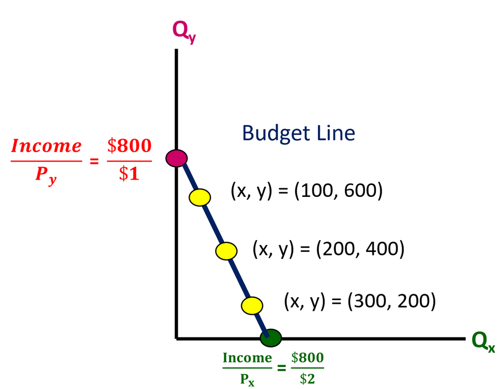

### The Constrained Optimization Problem

The approach involves applying utility maximization. The notation indicates maximizing by choosing different levels of X and Y for the utility function, subject to the budget constraint. The budget constraint states that the price of X times the number of units of X purchased, plus the price of Y times the number of units of Y purchased, equals total expenditures. For this to be feasible, that total must be less than or equal to income I.

The problem is: maximize utility by choosing X and Y such that the combination is actually affordable, given prices and income. This departs from introductory economics, which presents the budget line without a framework applying a decision rule to optimize within that setting.

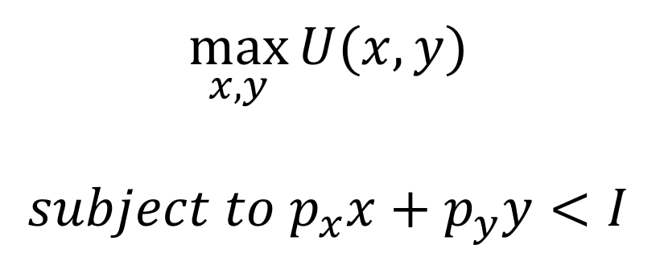

When discussing rational agents and all the assumptions of Homo economicus or perfectly rational decision makers, this is actually what they are assumed to be doing: somehow examining all possible combinations of X and Y, or thousands of goods, and rationally and correctly optimizing this mathematical equation.

## Applying Utility Theory: The Beach Exercise

### The Challenge of Valuation

To unpack constrained optimization, consider a brief exercise. Suppose there are $1,000 to spend on fun activities, with the options being: A, go to the beach; B, go to an indoor water park; or C, sit by a backyard kiddie pool. The task is to allocate that $1,000 across these three options, spending it all. The allocation could be $333 for each, or all $1,000 to the beach with nothing to the others.

This exercise is genuinely difficult. Information about prices is missing. Also, sitting by a backyard kiddie pool might be fun once, but $1,000 could cover doing that all summer long. Even with only partial information, without knowing the prices, and even if prices were provided, it would not be enough to do the exercise quantitatively because the number of units of utility from each activity is unknown. The point of rational utility maximization is assuming that all sorts of different bundles, including unusual ones, can be accurately analyzed within the utility framework.

### Environmental Goods and Utility

Putting a numerical measure on going to an indoor water park is challenging. But saying how much utility comes from simply knowing that a kangaroo exists is even harder. Or consider a species that one knows will never be seen. There would likely still be some positive value assigned to that existence, even knowing the species will never be personally encountered.

This sets up a recurring theme: utility theory makes many assumptions that work reasonably well for items purchased at Target, but the assumptions become harder to apply when analyzing anything about the environment. Nonetheless, utility theory assumes people are perfectly rational, can perfectly rank different options no matter how different they are, that resources are scarce, and that people are well-informed with preferences over all possible combinations.

## Solving the Optimization Problem Graphically

### The Lagrangian Approach (Briefly)

The mathematical method for solving constrained optimization problems is the Lagrangian, which is covered extensively in intermediate and advanced microeconomics. It is elegant mathematics and beautiful, serving as the workhorse behind solving what a rational agent would do when facing such decisions. Given goods and prices, one maximizes over all choices subject to the budget constraint. The Lagrangian is a mathematical way of solving for optimal choices.

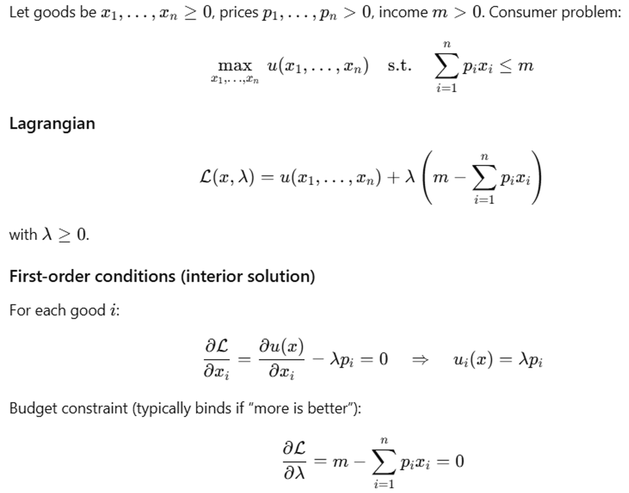

### Graphical Analysis with Indifference Curves

Instead of the Lagrangian, this lecture uses graphical analysis, which is mathematically identical. Anything done graphically can be computed mathematically. Where this approach departs from introductory economics is spending more time on indifference curves, which are typically not discussed in introductory courses because those courses do not address utility maximization and revealed preferences.

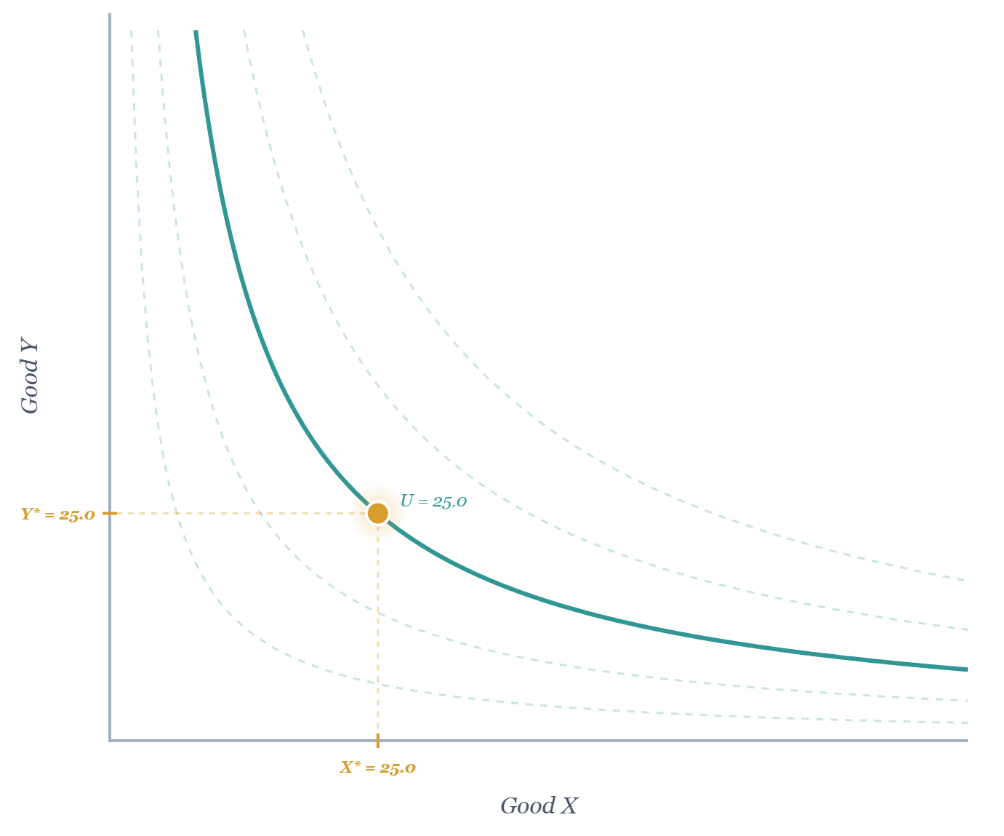

### Dynamic Indifference Curve

[interactive chart not shown]

### What Is an Indifference Curve?

An indifference curve represents a relationship between two different goods, with good X on the x-axis and good Y on the y-axis. An indifference curve is a line showing all combinations of Y and X that leave the consumer indifferent. This sounds somewhat odd, so consider it more carefully.

The curve typically looks like a downward-sloping arc where utility is the same for every point on that indifference curve. This means equal happiness with a lot of X and only a little Y compared to a lot of Y and only a little X. All points on the curve generate the exact same number when plugged into the utility function.

This explains why it is called an indifference curve: there is indifference between different points on the curve. For any two pairs of goods, like pens and notebooks, consider whether it is better to have 100 pens and one notebook or 100 notebooks and one pen for school success. This is difficult to answer, but some relationship exists, some combination where utility is roughly equal between different options. It simply expresses different bundles between which there is indifference.

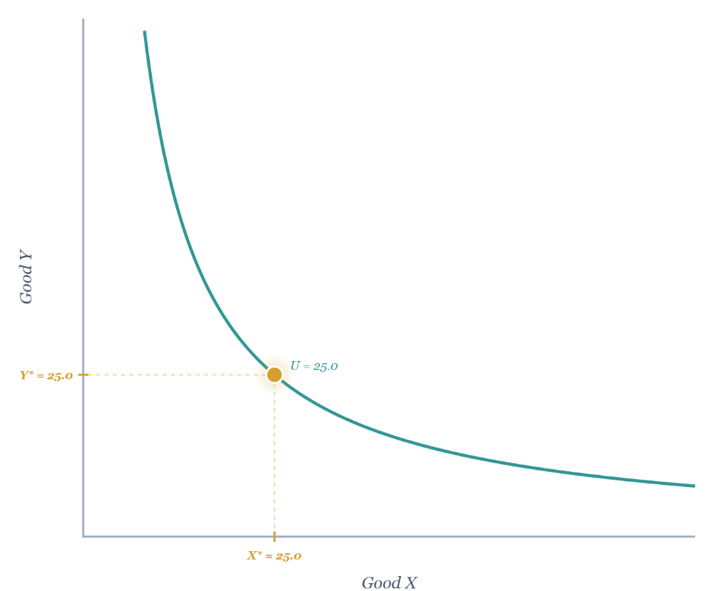

### Properties of Indifference Curves

Multiple indifference curves can be imagined. As consumption increases, having more X and more Y with more budget to spend allows for improvement by getting more of both. Indifference curves, moving away from the origin up and to the right, represent new curves. They are still indifference curves where utility is the same at any point on that curve, but they continuously move outward.

The typical shape drawn relates to the law of diminishing marginal returns from introductory economics. The classic example is: if starving, how much utility would come from successive slices of pizza? The first slice provides tremendous utility due to hunger. The second, third, and fourth provide considerable utility. By the fifth slice, satiation begins. By the sixth, fullness sets in, and at some point eating stops because the additional utility or happiness from eating reaches zero.

This is described as a law because many real-world phenomena, both in consumption and production, exhibit diminishing returns. In the consumption case, with diminishing returns, as more of one good is accumulated, the relative value of the other good increases. Shapes like the typical indifference curve indicate that a mix of X and Y will often be optimal.

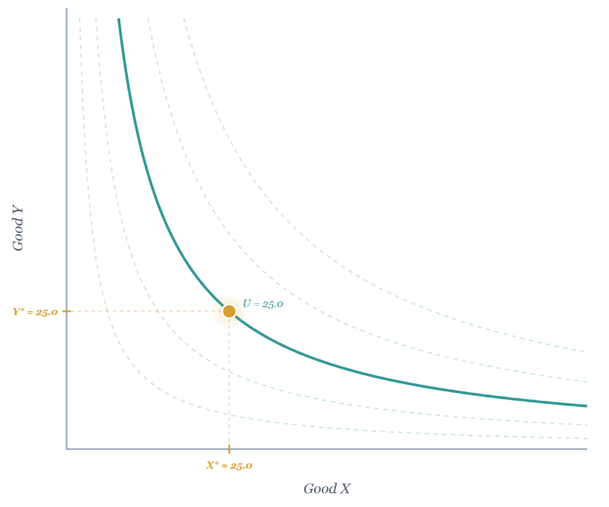

### Specific Examples with Goods

The normal case is that more is better, but a mix is best. This is the key takeaway from indifference curves and their typical shape.

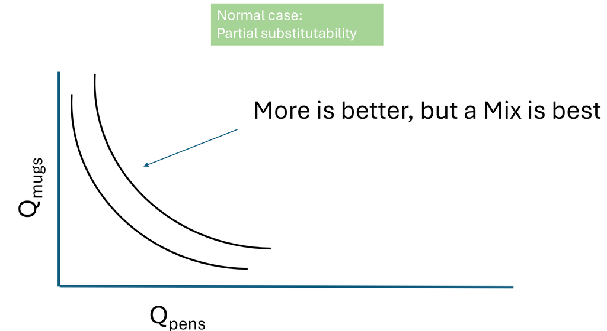

### Perfect Substitutes

The analysis can be extended to other extremes. A curve could be a perfectly straight line. This is called perfect substitutes, where the value of an X is exactly the same as the value of a Y, making a one-for-one exchange comfortable with no real value from having a mixture. An example might be blue pens versus black pens. One might argue that black pens are superior to blue pens, which would make the curve slightly bowed. But more or less, a blue pen is a pretty good substitute for a black pen for note-taking, so the curve would be closer to flat.

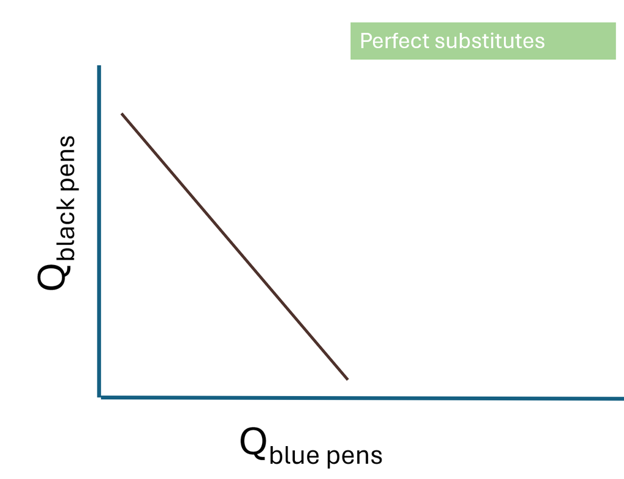

### Perfect Complements

Perfect complements represent the opposite extreme. Instead of being straight, the curve bows inward so far that it reaches an extreme case where it is bowed as much as possible, creating an L-shape. The classic example is left shoes compared to right shoes. For collectors, having just left shoes might be acceptable. But for walking, the value of a left shoe is only obtainable with a right shoe. There is no substitutability. Having two right shoes provides far less happiness than having one right and one left shoe.

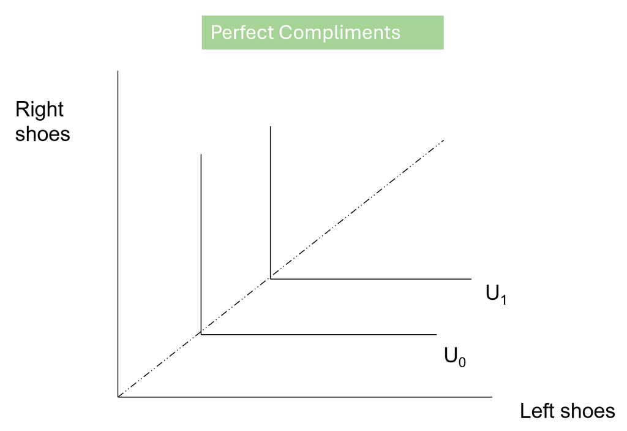

## Utility Maximization with the Budget Constraint

### Combining Indifference Curves and Budget Constraints

These indifference curves will be used to solve the optimization problem. Instead of the Lagrangian, the budget constraint will be added to the indifference curve analysis. The indifference curve describes the utility function; the budget constraint is what gets added.

With mugs and pens as goods X and Y, plugging them into the budget constraint function shows the constraint. If all money were spent on mugs (good Y), the amount that could be purchased depends on income and price. With $800 of income and a price of $1 per unit of mugs, 800 mugs and 0 pens could be purchased. That is one point. Conversely, buying all X means spending zero on the other good. The budget constraint is simply the line connecting these endpoints.

This takes a step beyond introductory courses by expressing it as a functional constraint, but the idea is the same. The purchasable set lies inside the budget line, and the things on the line are purchasable with all money spent.

### Finding the Optimal Point

Drawing indifference curves on the budget constraint reveals the solution. Consider a utility level U0. The consumer is at U0 units of happiness, but could things be better since the goal is to maximize utility?

This contrasts with wishes for more. More utility would come from reaching a higher indifference curve, but that is not possible given the budget. Not enough money exists to purchase any combination on higher curves. Constrained optimization, the Lagrangian, or any other method, simply gets to that utility-maximized point where the two curves just barely touch.

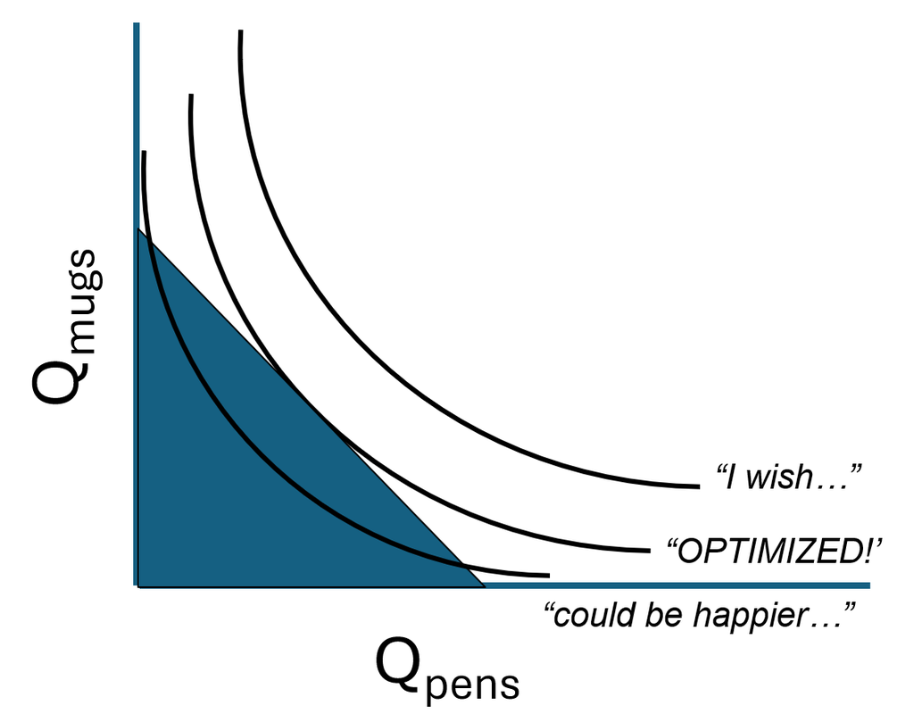

### Utility Maximization Game

[interactive chart not shown]

### Why This Matters

This is interesting for two reasons. First, it provides a way of solving the optimization problem. Second, it offers a powerful way to predict how human behavior might react to changes like price changes. Prices constantly change, and those changes affect purchasing decisions.

If the price of pens increased, the budget curve would rotate inward. The utility maximizing approach still works, but there would be a loss of utility. The previous indifference curve is no longer attainable, requiring a fall back to a lower curve.

This directly illustrates, from a utilitarian philosophy perspective, why price increases are bad. Applying this to all of society, jumping ahead conceptually, society itself would be worse off, so whatever caused that price increase is a bad thing, ceteris paribus. This ties back explicitly to philosophy and morality.

### Summary of Consumer Theory

Tying it all together, the graphical solution is the same as the mathematical solution. Consumers choose whatever bundle of X and Y maximizes their utility from the set of affordable bundles. Mathematically: maximize U(X,Y) subject to PxX + PyY ≤ I.

This represents the combination of basic consumer theory. The concepts should be review, but having them fresh in memory is valuable for what follows.

## The Cobb-Douglas Utility Function

### Specifying a Functional Form

Usually the utility function is not specified. It is more useful to think about it as some unspecified function satisfying the preference relationship, without caring about the specific numbers. However, to actually mathematically optimize, a specific shape must be given. This course will use Cobb-Douglas utility functions.

Instead of the general form, the Cobb-Douglas provides a specific computable form: the number of units of X raised to the alpha power times the number of units of Y raised to the (1-alpha) power. Based on alpha, different shapes of indifference curves result, but all have the standard convex bowed-in shape. This will be used throughout.

## Interactive Tools and Visualization

### Web Applications for Exploring Utility Theory

To develop an intuitive sense of indifference curves, web-based tools are available on the course website. Under the Games tab, also found under Micro Foundations (the micro-filling), there is a list of games to play.

A web app has been programmed that illustrates what happens when different variables change. As discussed, if the price of Y increases, the budget line rotates. The app allows playing around with all the different variables and trying out different levels of alpha to see what a Cobb-Douglas looks like, observing how it bends the relative importance of one good versus the other.

[interactive chart not shown]

### The Utility Maximization Game

An interactive game allows playing with these concepts at home. Different combinations of X and Y can be tested to see which yields the most utility. The current utility is displayed as a function of the quantities of good X and good Y. It changes as combinations vary, but going past the budget constraint is not possible since those combinations are unaffordable.

[interactive chart not shown]

### Extensions to Higher Dimensions

The claim that utility theory works for any number of goods was made earlier. So far, only two dimensions have been considered. But in three dimensions, the Cobb-Douglas takes a similar form with X, Y, and Z, and all coefficients summing to 1. The same idea holds: as more of X is produced, curves shift. The optimum occurs when the indifference surface is just tangent to the budget constraint, which, with three goods, becomes a plane instead of a line.

The logic can be extended further: four dimensions using color as the fourth dimension, five dimensions, and even a user interface allowing sliders to optimize a utility function subject to a budget constraint with 15 goods and 15 prices. This was accomplished through “vibe coding,” using AI to make things very rapidly. While vibe coding is often considered problematic, it enabled creating these applications in minutes rather than the long time it would have taken previously.

[interactive chart not shown]

## Connecting to Environmental Economics

### The Central Challenge

The fundamental goal is developing an intuitive sense of this beautiful mathematics. It forms the fundamental core of the moral basis of utilitarianism, but also the fundamental challenge for environmental economics: how to value things that may not have a clear quantification method or price.

The next assignment will involve playing around with one of the interactive tools. The goal is building intuition for utility maximization while recognizing its limitations for environmental goods. This foundation will be used throughout the semester when addressing cost-benefit analysis and other environmental decision-making tools.

### Looking Ahead

This lecture intentionally built out the full chain of logic from utilitarianism through revealed preferences to utility maximization, because this chain is embedded throughout environmental economics. The challenges identified at the beginning, especially the ordinal nature of utility and the aggregation problems, become particularly acute when dealing with environmental goods. How to value the existence of a species, the aesthetic value of watching trees grow, or the well-being of future generations facing climate change all require grappling with these foundational concepts. Future lectures will address specific tools for dealing with these challenges while keeping these philosophical foundations in mind.

# Transcript

Okay, so welcome to Lecture 3, which I have, hopefully in a hilarious way, named “The Micro-Filling.” One of the themes of this course is the concept of the planetary donut from Kate Raworth that we talked about last class when we looked at those indicators.

I want to go a lot farther than that book did. That book did not talk about this—this is fresh content. I will contend throughout this course that economics is really awesome for a variety of reasons, but one of those is it has a super good, coherent theory of why people make the decisions that they do.

As I said in the other class, I often find myself being an apologist for economists. That’s just because I’m always finding myself among a bunch of environmentalists, many of whom hate economists because they just represent the capitalist system or whatever. And so I’m always trying to argue for the importance of both environment and economics. Maybe I don’t need to convince this crew, but it still is a useful way to talk through what is the value of an econ major and the tools that we can learn.

And so that’s what I’m calling the micro-filling—this donut, when embedded in a detailed economic model, has a whole lot of depth to it and really valuable details that we can use to make predictions about human behavior. That’s what this hilarious AI-generated image is illustrating here. Although, you know, if I were to grade this, it might look familiar to you from your undergrad classes. It’s got supply and demand pretty good, but this one’s not quite right. The minimum of the marginal revenue curve does not intersect the average total cost curve, and so I would give this person a markdown. Anyways.

What we are going to talk about today more specifically is utility. Utility is the fundamental thing that economists use as a concept for arguing that the policies of the invisible hand or the free market are good, and we’ll get into that. But first, we need to learn about the tools of utility, utility curves, and how individuals who we assume to be rational will optimize their utility. We’ll talk about the tools of constrained optimization.

This is in the line of maximizing welfare. If you had unlimited resources, it’s a pretty boring question—you could just have unlimited consumer goods. But in reality, we have constrained choices, constrained by our budget. Then I’ll tie this back together about how this all relates to the environmental aspects and how we’ll use it for the rest of the semester.

Okay, so what is utility? We will use it throughout, but I think it’s useful to think about its philosophical origins. Modern welfare economics is something that grows directly out of utilitarian moral philosophy.

Unpacking those terms a little bit, we’re going to be using the word “welfare” in a very specific way, and it has nothing to do with how most people use the word welfare. Most people think about government assistance programs when they think about welfare. They’re called that because those programs are aimed to increase welfare, but when we say welfare as economists, we’re going to mean something very specific. We’re going to unpack that here today, but previewing, it’s a little bit related to utility maximization and consumer and producer surplus, if you remember those concepts.

The philosophical basis comes from Bentham and John Stuart Mill, who were the two most notable proponents of utilitarianism. I love this philosophy because it’s really simple to summarize. The most common phrase is maybe “the greatest good for the greatest number of people.” Or to use their actual quotes, “the right action is the one that maximizes total happiness.”

This has been used throughout. It’s very different from a rights-based approach. It sounds all good, but you should just be aware there’s a huge philosophical disagreement about utilitarianism and whether it is the right way to think about morals, or something that is rights-based. These two are fundamentally in conflict. If you say you have a right to free speech, or free expression, or protest, or not being detained, that is a right that might conflict with what utilitarianism says, because maybe a utilitarian might argue that that right prevents us from doing the thing that would maximize utility.

So we’re not going to dive deep into philosophy, but it’s just interesting to note that there’s a deep contradiction or deep debate here. We’re going to use it, though, because it’s useful. We’re pragmatists. In economics, this is a useful framing because we can take it and run with it, run really far. We will posit that each person has a utility function, that social welfare is basically some aggregation of everybody’s utility functions, and that, therefore, the utilitarian or normative good policy would simply be the one that maximizes the sum of utilities. We’re going to unpack that.

But before we do, I want to talk a little bit about the challenges. Oftentimes, people present a whole theory and all of its detail, and only at the end present the challenges. I want these to be present in our mind from the beginning.

The first one is that utilities are something called ordinal, which means we can only figure out the order. What this means is when we use utility as a concept, we can easily say that one bundle of goods gives us more utility. It’s ranked in order before some other bundle, so we know the order of how we might care about different consumption choices. That’s what ordinal means.

It’s a little bit different than something cardinal, where we actually get a real measurement. A cardinal measurement would be like that of a thermometer. You stick a thermometer in, you get 98 degrees, and that actually means something. But when you have utility, it’s not like that. You will get a number, and we’ll see that, but it doesn’t mean anything. There is no unit of utility like there is a measurement of temperature. So the first challenge is that it’s hard to measure. And it’s private—we can’t observe it directly. This is a sort of fraught thing to be dealing with, unobservable directly. But we will talk about some ways that we can learn a lot about the shape of what it might look like.

The second set of challenges are bundled together as aggregation ones. I really quickly went through the idea that we can sum together our individual utility functions. Turns out that’s a really challenging thing to do in a way that is value-free. However you sum people’s utilities together, you fundamentally are bringing in values. If you sum them equally, that’s saying equality matters. Or you might sum them according to some sort of distribution rule, like we shouldn’t have anybody who is really poor. I just want you to keep those in mind. It’s especially important because how we aggregate society’s welfare into a utility function that represents everybody is going to be fundamentally challenging in terms of debates between equality versus efficiency.

We’re going to see a lot of that in upcoming classes, especially with respect to present value versus future generations. How you care about somebody born 100 years from now and whether or not they’ll be struggling with an unstable climate—that’s a really tough question. How much should we care about that person? We’ll return to that extensively when we talk about the discount rate.

Okay, so those are the challenges. I say it can’t be observed directly, but there is a very deep amount of thinking and theory behind what we can observe and what we can try to use in a computational setting.

Although we can’t observe utility, we can infer things about it from observed behavior—revealed choices or revealed preferences. This is about going from unambiguous observed data to a utility function. We don’t know how many units of utility we get, but we can say preference information, like “I prefer A over B.” That can be observed by, for instance, did I buy A instead of B? So this is stuff that is data. You can observe it directly from a person in a store or by asking them.

An example might be: suppose the options that I’m choosing from are A, B, and C. A might be a bundle of goods and services called “Go to the Movies.” B might be “Go to a Museum,” and C might be “Watch Trees Grow.” Any given person, or at least the theory of revealed preferences would say, any person can make a mapping of how they prefer one option to the other. It’s saying some statement like, “I prefer going to the movies over the museum, and I prefer the museum over watching a tree grow.” It doesn’t have to be that order. All revealed preferences requires is that these preference relationships are known and can be expressed.

From there, the one big leap is that economists argue you can make a utility function that is compatible with all of those observed preferences. This is going to look almost like the same thing, where here we’re going to say the utility from choice A is greater than utility of choice B, and also the utility of B is greater than the utility of C. You can see how this is really similar to the preference ranking. But we’re positing that we can plug it into a numerical function that will give us output numbers. We don’t know what those numbers are or what can be interpreted from them. There is no such thing as an observable unit of utility. Sometimes people jokingly call it a “util,” but rather we’re just arguing that we could create these functions that preserve the ordering of preferences.

Now, I’m curious, who here has had the intermediate level microeconomics? It’s one of those things that there’s a lot of debate on whether or not it’s even worth talking about preferences in an intermediate course. Some people do, some people don’t. But when you get into PhD-level economics, you spend a whole lot of time on this, because this is the fundamental reason why economics claims to be good, or correct, or powerful.

A phrase that you might hear me say a number of times when I’m criticizing economics is that they struggle, sometimes, with what I would call “physics envy.” A lot of economists want to see the world and the theories they create in economics as something akin to physics—like we can get fundamental truths about human behavior. And who’s seen the movie A Beautiful Mind? It’s about John Nash. Great movie if you’re looking for a recommendation. He’s doing fundamental mathematics, and we’re exposing the beautiful relationship, sort of like Newtonian physics, about how a ball flies through the air, but applied to the complexity of humans.

I think that’s kind of a really dangerous way of looking at it, because humans are so much more complex than a ball flying through the air that it can be very challenging. But a PhD in economics spends a lot of time on preferences and mathematical theorems that you can use on the preferences or on the utility functions.

That’s kind of an aside. The reason I want to emphasize it is because unlike in a standard intermediate or advanced undergraduate microeconomics course, this course being about the environment deals fundamentally with hard-to-value things, like what is the value of watching a tree grow, or what is the value of the existence of a species? And so I’m spending more time, and I decided to do this on purpose, of building out the utilitarianism, revealed preferences, utility maximization chain of logic that we’re going to use throughout, because this is embedded in our environmental decision-making, like cost-benefit analysis, where we’ll learn specific tools.

All I want to make clear is that it is a huge leap that we think we can put a specific number on all different things, like how many units of utility would I get from contemplating a painting in a museum? It’s hard. But we’re going to do it, because it’s useful. And it’s useful because it’s predictive.

Let’s start to define a few things. We’re going to walk through consumer preferences. We’re going to talk about the utility function. We’ll denote it throughout as capital U. Like any function, it has some inputs into the function. For the moment, we’re not going to specify all that much detail, other than to say we have two different goods that we might consume, good X and good Y. Hopefully this is review from your intermediate course, but I want to dig deep. X is just the number of goods of unit X that you can purchase, and Y is how many Ys you could purchase. When you plug those two quantities into the utility function, you get out that utility metric.

In principle, you could have a ton of different goods going into this. A real consumer is not considering just two things, but a choice of thousands of choices per day. I don’t know how many choices we make per day, but lots and lots. This mathematics is beautiful because it all scales up really well. You can do utility maximization with really a lot of goods. We’ll stick with two, though, for most of the drawings.

Okay, so the utility function by itself is not super interesting, because we can just get more utility by plugging in more and more and more. But economics is, you might remember, the study of choices under scarcity. For this to be useful, we need to have something that is scarce, and that’ll be, right back from Econ 101, the budget.

You might recall that you actually saw this figure if you took it with me—the way you can combine information on income and prices. Where the price of good Y is something, and the price of good X over here is something, you figure out what is your budget line. The budget line is just the outer bound of what you could afford. Everything inside this line is affordable. Everything outside of that line is unaffordable. And everything right on the line—it’s affordable, but you spent all your money. This is going to be used because we’re going to maximize our utility subject to it being possible.

So let’s unpack that. The real thing we’re going to do is apply this maximization approach. It’s nice to note that the notation here is just saying we’re going to maximize by choosing different levels of X and Y, this function. But it’s going to be subject to the budget constraint. I’ll write it two ways, but we’re going to jump straight to how we express it using the information we have.

The budget constraint is the price of X times the number of Xs you buy, plus the price of Y times the number of units of Y that you have, and so that’s just your expenditures. But for it to be feasible, that needs to be less than or equal to your income I.

So, maximize utility by choosing X and Y such that you can actually afford it, given the prices and your income. This is where we’re departing from Econ 101, where it’s just “this is the budget line and so on,” to a framework that applies a decision rule, utility maximization, to optimize it in that setting.

When we talk about rational agents and all the assumptions that Homo economicus or these perfectly rational decision makers have, this is actually what we’re saying they’re doing—that they can somehow look at all the Xs and Ys, or the thousand goods that they’re considering, and rationally and correctly optimize this mathematical equation.

We’re going to unpack this with a very brief in-class exercise. You don’t even need to get up for this one and relocate. I want you to put a dollar value on something. We’re going to do a constrained optimization. I’m not going to give you all the details you need, like you would love to know the price. But just talk it through in your head.

Suppose you have $1,000 to spend on fun activities, and the different options are: A, go to the beach; B, go to an indoor water park; or C, sit by a backyard kiddie pool. Just jot down those three numbers with the constraint that you can’t spend more than $1,000. You could spend $333 for each of the three, or you could do all $1,000 to the beach and nothing to the other ones. For simplicity, spend it all.

I think this is really hard. One of the things you don’t know is the price. Also, sitting by a backyard kiddie pool—that might be fun once, but for $1,000, I could probably do that all summer long. It’s hard, right? There’s a whole lot of information you don’t know.

Okay, so we do have different preferences here. This is the point—this is hard to figure out. There’s a whole lot of information you don’t know. What I want to do is to say that, in this example, we can, in principle, think about how we would allocate our money or choices towards different activities, even though they’re really different.

And even with only sort of partial information, I intentionally didn’t give you the prices. Even if I had, though, it wouldn’t have been enough to do it quantitatively, because you don’t know how many units of utility you would get from that unit. The point of rational utility maximization is assuming we can have all sorts of different bundles, including ones like the existence of kangaroos, that we can accurately analyze in our utility framework.

I would have a hard time putting a measurement, a number of utils, on going to an indoor water park, but I’d have an even harder time saying how much utility do I get from simply knowing that a kangaroo exists. Or maybe even a species that I know I’ll never see. I’ve actually seen a kangaroo. So a species that I haven’t seen—I still would probably assign some sort of positive value to that existence, even if I knew for sure I was never going to see it.

This is just setting up that in utility theory, we do make a lot of assumptions. They work pretty well for things that you might buy at Target, but they start to get a little bit harder to compare when we do analysis of anything about the environment, and so that’s going to be a recurrent theme that we have throughout.

But nonetheless, it’s just the case that utility theory assumes people are perfectly rational, that they can perfectly rank these different options, no matter how different they are. And a few other things, like resources are scarce, and that they’re well-informed and have preferences over all the possible combinations.

Okay, so that’s just kind of the challenge. But how do we solve this? Who here has done a Lagrangian? Even the PhD students—right after we do preferences and revealed preference, we then do Lagrangian. We’re not going to do this, okay? That was important if you were taking the intermediate or advanced micro. It’s really awesome mathematics. It’s beautiful, I love it. And it is the sort of workhorse behind solving mathematically what would a rational agent do when they face a decision like this, or even a potentially more complex version of this.

Basically, you can see it’s given goods and prices, maximize over all those choices, subject to the budget constraint. That’s the setup, and then the Lagrangian is just a mathematical way of solving for the optimal choices of X, and you can do it with beautiful mathematics.

We, instead, are going to do it with hopefully beautiful images. This is going to be a graphical analysis, but keep in mind, this is identical, in fact, to the mathematics, and so anything we’re going to do here, you can plug into a computer and do it that way.

Where we’re going to depart from your Econ 101 course, though, is we’re going to spend more time on indifference curves. Most people in an Econ 101 don’t talk about indifference curves, and that’s because it doesn’t talk about utility maximization and revealed preferences. But we are going to talk about them directly.

So first off, what is an indifference curve? An indifference curve is going to be a relationship between two different goods. We’re going to use good X on the x-axis and good Y on the y-axis. An indifference curve is a line that is a combination of all combinations of Y and X that you are indifferent between.

That sounds kind of funny, but let’s plot it out. It’s going to be a curve, and it will often look like this, where the utility is the same for every point on that indifference curve. What that’s saying is I would be just as happy with a whole lot of X and only a little bit of Y as I would be if I had a whole lot of Y and a little bit of X. All of the points on there would generate the exact same number when plugged into our utility function.

That’s why it’s called the indifference curve. It’s like, well, I guess I’d be indifferent between here and here. It’s sometimes hard to think about what those would be, but if you’re thinking about any two pairs of goods, like pens or notebooks—if you’re wanting to do good in school, would you be better off with 100 pens and one notebook, or 1 notebook and 100 pens? That’s hard to say, but there’s some relationship, some combination, where you’re roughly at the same utility between those different options. It’s just a way of expressing different bundles that we are indifferent between.

But we might be able to think of multiple indifference curves. As you consume more and more, obviously if you have more X and more Y, just more budget to spend on things, you could get even better by just getting more of both. Indifference curves, as you go away from the origin, up and to the right, you get new curves. They’re all still indifference curves where you’re at the same utility on any point on that curve, but they continuously move outward.

One of the reasons for the shape that we’re drawing, what I said is the typical shape, is in intro econ, you spend a lot of time talking about the law of diminishing marginal returns. Just to reiterate, that’s like the example of if you’re starving, how much utility would you get from X number of slices of pizza? You’d get a ton of utility from the first, because you were starving. A lot of utility from the second, and third, and fourth, and the fifth, you’re starting to get full. The sixth, you’re getting really full, and probably at some point, you would just simply stop eating, because the additional utility or happiness you get from eating goes down to zero.

This is described as a law because so many things that we see in real life, both in terms of consuming things like pizza, but also producing things, exhibit diminishing returns. In the consumption case, when you have diminishing returns, as you get more and more, the relative value of the other thing goes up. I’ll leave it to you to satisfy your curiosity by looking into this later if you’d like, but just know that shapes like this indicate we’ll often have a mix of X and Y.

The key thing that we get from this—so now let’s put some specific units on it. We might have the quantity of pens and the quantity of mugs. This is that normal case where we’ve talked about, where I think few people would want to live a life where they have lots of pens and no mugs. What do you drink your coffee in? Or live a life where you have only mugs and no pens to write your notes on. So it bows out like this, indicating partial substitutability. The more bowed it is, the less substitutable the things are.

The normal case is just more is better, but a mix is best. That’s kind of the takeaway from indifference curves and their normal shape.

But it also can be extended to think about other extremes. We could also have a curve that’s a perfectly straight line. This is called perfect substitutes, where the value of an X is exactly the same as a value of a Y, so you’d be comfortable with just changing one for one, and there’s no real value of having a mixture of them. This might be blue pens or black pens. You might push back to say black pens are just superior to blue pens, right? That’s my preference. So that would just be a little bit bowed in. But more or less, you can see that a blue pen is a pretty good substitute for a black pen for taking notes. So it would have a curve that is closer to flat.

But if you had something that was perfect complements, that would be the opposite. Instead of being straight, it gets bowed, and it gets bowed so far that it hits this extreme case where it’s bowed as much as it can get. The classic example of perfect complements would be the number of left shoes you should buy compared to the number of right shoes you should buy. You could push against this. Maybe if you’re a collector of shoes, you’d be okay with just a lot of left shoes. But if you use them for walking, it’s probably the case that the value of the left shoe is only obtainable if you also have a right shoe. There is no substitutability. I would not be happy if I had two right shoes. I’d be much happier if I had a right and a left shoe.

Okay, so those are all just different indifference curves. And we are going to use them to solve this problem. Instead of the Lagrangian, we’re going to apply it to our utility maximization problem, and we’re going to note that the key thing we’re going to add is our budget constraint. The indifference curve is describing the utility function. The budget constraint is what we’re going to add.

So now, same goods, mugs and pens again—that’s the X and Y that we could have plugged into our utility function, but now we’re going to plug them into this function, and that is going to be our budget constraint. If we spent all of our money on mugs, which we’ll call good Y, how many we could buy depends on what our income was and what the price was. So if we had $800 of income, and the price of a unit of Y of mugs was $1, we could buy 800 mugs and 0 pens. That would be that point. Conversely, if we bought all X, it depends on the price of X. But we know for sure it’s going to be somewhere on this axis. If we spent all of our money on pens, we would have zero that we spent on the other thing. The budget constraint is just that line.

So here’s where we take a step beyond the intro course—now we’re expressing it as a functional constraint, but it’s the same idea as you had there. This set is the purchasable set, and the things on the line are the purchasable ones where you actually spent all your money.

Okay, so here’s the fun part. When we start to draw indifference curves on it, what if we had a utility of this amount, call it U0? How happy are we? Well, we’re at U0 number of happy, but the question is, could we do better? We want to maximize our utility.

If we chose something like this point, that combination of pens and mugs, we would get this amount of utility. That’s good, but could we do better? Well, yeah, you can kind of see, slide it to the upper right. This line here is the “could be happier” line. And we would keep on getting happier until, call it U1 star—star because it’s optimal. This is the optimized one, and what’s interesting here is now there’s a single point, the point of exact tangency. This amount of pens and this amount of mugs is optimal.

But that’s in contrast to the “I wish” scenario. Yes, you would have more utility if you somehow got out to here. But that’s not possible. You don’t have enough money to purchase any of those. And so constrained optimization, the Lagrangian, or whatever way you choose to do it, is just getting us to that utility-maximized point where the two curves just barely touch.

So why is this interesting? Number one, it’s a way of solving it. But number two, it gives us a powerful way to predict what might change and how human behavior might react to, for instance, price changes. Prices are constantly changing in the news, and that changes what we might want to buy.

If the price of pens went up, instead of being all the way out here, the budget curve would rotate inwards, and you might remember this from 101. What’s nice is the utility maximizing approach still works, it’s just that we would have a loss of utility. Now, this existing previous indifference curve is not attainable, and we’d have to fall back to this one.

This is a direct way of saying, from a utilitarianism philosophy perspective, why price increases are bad. Because now, if you apply this to all of society, jumping way ahead, you would see that society itself would be worse off, and so whatever caused that price increase is a bad thing, ceteris paribus. We’re trying to tie this back explicitly to philosophy and morality.

Basically, tying it all together, just to summarize: this thing is the same as this thing. Consumers are going to choose whatever bundle of X and Y maximizes their utility from the set of affordable bundles. So, max U of X and Y subject to PxX plus PyY being less than or equal to your income.

And so that is the combination of basic consumer theory. Any questions on this? Hopefully this is review, but I want to get it real fresh in our memories.

One last technical thing is usually the utility function is not specified. It’s just more useful to think about it as some unspecified thing that satisfies the whole preference relationship, but we don’t really care about the number. Well, if you want to actually mathematically optimize, you need to give it some sort of specific shape. And so we will actually be using what are called Cobb-Douglas utility functions.

That’s just going to be something that now, instead of the general form here, it’s going to give it a specific computable form. So the number of units of X to the alpha power times the number of units Y raised to the 1 minus alpha power. Based on alpha, you’ll have different shapes of this indifference curve, but they’ll all have that sort of standard convex bowed-in shape, so we’ll use that throughout. And it’s a nice, convex curve.

Okay. I want to do an unnecessary pivot here to describe what happened to me this morning. I sat down to do these lecture notes, and I got really excited about it. Again, I’m prone to do this, and I fell for the AI trap. I started using AI to make something funnier and funnier and funnier until it became over the top.

So first, let me just give you an archetype of the running joke about AI that I always have. This is right after DALL-E came out, and we could start to generate images, and so I gave it a basic prompt: “Generate an image of a cat on a chair.” It gave us an image of a cat sitting on a cozy chair, but this is like my personal hobby. I don’t know what this says about me, but I like to push things to the limit until they break.

So, okay, make it cozier. Alright, yeah, that’s an updated image, a little bit cozier, with a cat in the armchair. Make it a whole ton cozier and fluffier. Okay, that’s getting pretty extreme. Let’s push things to the brink—make this insanely more cozy. I can’t overestimate how cozy I want this to be. Millions of times cozier. And you start to push it. Now we add infinite coziness. Oh, but that’s not even nearly floppy enough, you can just keep on going, and I have a lot of fun with this.

But what I did today, and this is just an admission, is I did that to Applied Economics. If you go to our website, I want to give you a tool that you can bring home to play around with to get an intuitive sense of indifference curves. If you go onto our website here, you’ll notice there’s a Games tab. It’s also under Micro Foundations, the micro-filling. Here’s a list of games that you can play.

I actually programmed up a web app that illustrates this, where you could say, what happens when our different variables change? I just talked about how if the price of Y goes up, it rotates the budget line. This little, that first link, will illustrate this. You can play around with all the different things. You can also try out different levels of alpha, so if you want to know what a Cobb-Douglas looks like, you can see it just kind of bends the relative importance of one thing versus the other.

But the thing I got distracted on and ended up wasting all my time on was making it into a game. At home, you can actually play this. You can see what combination of X and Y gets you the most utility. You can see our current utility over there. It’s a function of how many good X and good Y we can get. We can see it changes around as we have different combinations, but we don’t want to go past our budget constraint because we can’t afford that.

I made this claim that utility theory works for any number of goods. So far, we’ve only been considering it in two dimensions, but what if you do it in three dimensions? This is what a Cobb-Douglas looks like with three dimensions. It’s that form, but XYZ and all the coefficients sum to 1. But the same idea holds—as you produce more of X, it shifts. It’s kind of hard to see, but you can see it’s shifting that curve. The same idea is now it’s optimal when it’s just tangent to the budget constraint, which, because we have three goods, is now a plane instead of a line.

But where this got ridiculous, I applied the cat logic—make it fluffier. And so now I have a series of other ones: okay, now do it in four dimensions. So it’s going to use color as the fourth dimension. Five dimensions… I even came up with a user interface that was able to let you drag around sliders to try to optimize a utility function subject to a budget constraint with 15 goods and 15 prices.

You might be wondering, how did I do this all right before class? The answer is vibe coding. Vibe coding is using AI to make things really, really fast, and it’s usually considered a negative thing. But on the other hand, it was able to make this in a matter of minutes. This would have taken me a long time before. So I’ll put those up, and once I confirm that everybody is able to load them, that will be our next assignment—play around with one of the ones, and I’ll give you more details on what it’ll be.

But I want you to have an intuitive sense of this, what I think is beautiful mathematics. Because it’s the fundamental core of the moral basis, utilitarianism, but also the fundamental challenge for the environment—how do we value things that maybe don’t have a clear quantification method of price?

So with that, let’s leave it there, and I’ll send you an update. There was no reading today, as you probably noticed, and that’s because I decided to write it on the fly, and that’s what this was. There may be a reading for next class, but I’ll always try to get it to you two days in advance. This course is generating itself as it goes, so I hope you’re okay with the patience of needing to see what to read coming right after class.

Thank you, everybody.

# Appendix

## Learning objectives

After this chapter, you should be able to:

- Explain what economists mean by **preferences** and **constraints**.
- Use the idea of **opportunity cost** to reason about environmental tradeoffs.
- Interpret a simple **budget constraint** graph.
- Explain why *every* sustainability policy involves tradeoffs, even when goals are noble.
- Connect microeconomic choice to the **Doughnut**: meeting human needs within ecological limits.

## Core idea: choices under constraints

Every person, household, firm, and government faces constraints:

- limited income or resources,
- limited time,
- limited land,
- limited political capital,
- and, increasingly, **ecological limits**.

Economics starts with a simple observation:

> You cannot have everything you want at once.

This is not pessimism—it is realism. Sustainability is not about escaping tradeoffs. It is about **choosing better tradeoffs**.

## Preferences: what people care about

In economics, *preferences* are a compact way of saying:

- what people value,
- how they rank alternatives,
- and what they are willing to give up to get something else.

Preferences can include:

- consumption of goods (food, housing, energy),
- leisure and time,
- health and safety,
- environmental quality,
- fairness or status.

Economics does **not** assume that people only care about money. It assumes only that:

> People can rank alternatives, even imperfectly.

This matters for environmental policy because people may value:

- clean air,
- nearby nature,
- climate stability,
- food security,
- and fairness across generations.

The challenge is that many of these values are not well represented in markets.

## Constraints: what people can actually do

Preferences alone do not determine outcomes. Constraints do.

For a household, a constraint might be:

- income,
- time,
- access to transport or energy.

For a society, constraints include:

- available land,
- technology,
- institutions,
- and biophysical limits.

In microeconomics, we often represent constraints with a **budget line**:

- On one axis: “more of X”
- On the other: “more of Y”
- The line shows all combinations you can afford.

The slope reflects **relative cost**: how much of Y you must give up to get more X.

Even without drawing the graph, the logic is simple:

> Choosing more of one thing means choosing less of something else.

## Opportunity cost: the hidden price of everything

The **opportunity cost** of a choice is:

> What you give up by making that choice.

Examples:

- Protecting a forest may reduce timber revenue or farmland.
- Expanding renewable energy may raise short-run electricity prices.
- Building a highway may destroy wetlands.

Opportunity cost is not an argument *against* protection.  
It is a way to make tradeoffs **explicit**.

Environmental debates often fail because:

- One side speaks in moral terms (“This must be protected.”)
- The other speaks in cost terms (“This is too expensive.”)

Economics forces both to confront the full picture:

- What do we gain?
- What do we give up?
- Who bears each side of the tradeoff?

## A simple choice problem

Imagine a city deciding how to use a fixed piece of land:

- Option A: housing
- Option B: urban green space

The city values:

- affordable housing,
- access to nature,
- heat mitigation,
- tax revenue.

The land constraint is real: it cannot be both fully built and fully preserved.

The question is not:

> “Should we care about housing or nature?”

It is:

> “How much of each best advances human well-being within ecological limits?”

That is a Doughnut question.

## Microeconomics inside the Doughnut

The Doughnut defines a target:

- Above the **social foundation**: people’s basic needs met.
- Below the **ecological ceiling**: Earth’s systems remain stable.

Microeconomics tells us:

- how individual decisions push us *toward* or *away* from that space,
- how constraints shape those decisions,
- and how policies can change the feasible set.

Think of the Doughnut as the **goal region**.  
Think of preferences and constraints as the **engine** that moves society.

Policies work by:

- shifting constraints (taxes, standards, access),
- reshaping incentives,
- and sometimes changing what is even *possible*.

## Worked example: energy choices in a household

A household chooses between:

- cheap fossil-based electricity,
- more expensive renewable electricity,
- or investing in insulation.

Preferences: - comfort, - cost, - environmental concern.

Constraints: - income, - housing type, - available programs.

Opportunity costs:

- Paying more for green energy means less for other goods.
- Investing in insulation means upfront cost for long-run savings.

Policy can change the problem:

- rebates lower the cost of insulation,
- carbon pricing raises the cost of fossil power,
- default enrollment changes behavior.

The household’s *preferences* may not change.  
The **choice set** does.

That is the micro foundation of environmental policy.

## Why this matters for sustainability

Sustainability is not achieved by hoping everyone becomes altruistic.

It is achieved by:

- designing institutions so that
- ordinary choices,
- under ordinary preferences,
- within real constraints,
- lead toward the Doughnut.

Microeconomics gives us the grammar for that design.

## Open resources you can remix for this chapter

All are compatible with a CC BY-NC-SA Quarto book.

- **Principles of Economics (UMN Libraries Publishing, CC BY-NC-SA)**  
  Use for: preferences, constraints, budget lines, opportunity cost.  
  https://open.umn.edu/opentextbooks/textbooks/principles-of-economics
- **InTeGrate teaching materials (many CC BY-NC-SA)**  
  Use for: applied activities linking choice and sustainability.  
  https://serc.carleton.edu/integrate/teaching_materials/index.html

You can adapt figures and explanations directly, with attribution.

## Exercises

1. **Opportunity cost in practice.**  
   For each policy, state one major opportunity cost:
   - 1. banning coal power,
   - 2. protecting 30% of land for nature,
   - 3. subsidizing electric vehicles.
2. **Preferences vs constraints.**  
   Give one example where:
   - people *want* a sustainable option,
   - but constraints prevent them from choosing it.
3. **Doughnut framing (short essay).**  
   Choose a sustainability issue (housing, food, energy, water).  
   Describe:
   - one way society falls short of the social foundation,
   - one way it overshoots the ecological ceiling,
   - and one micro-level policy that could shift choices toward the Doughnut.

## Chapter roadmap

- Next: how individual choices aggregate into **markets**.
- You will learn how supply and demand translate preferences and constraints into prices, quantities, and welfare.
- Then we will see exactly how and why markets fail for environmental goods—and what can be done about it.